# Northern Three Spatial Analyses (eReefs Stars method validation)

- Show All Code
- Hide All Code
- View Source

Author

Adam Shand

Published

October 27, 2023

**R Version**

For R session info at the time of rendering this script see Section 5.

**Note**

This is one part of several scripts exploring CSIRO ereefs data.

# 1 Introduction

This script is a supplementary script written to validate the data obtained using the Stars method. The script compares stars numbers against numbers obtained directly from the raw data (using the AIMS method), and against in situ loggers. The purpose of this script is to ensure that the numbers obtained using the stars method are representative of the raw data, it is not a statistical analysis of the accuracy of the data relative to the real world. For a rigorous statistical analysis of eReefs models refer to the eReefs website, or see the document in the reference library: “references/other_documents/ereefs_statistical_validation.pdf”

# 2 Script Set Up

The chunk below installs/loads packages.

```r
library(terra)
library(stars)
library(glue)
library(here)
library(ggplot2)
library(sf)
library(tidyverse)
library(ereefs)
library(tmap)
```

Then set variables and save locations.

```r
#set project crs
proj_crs <- params$project_crs

#create a file path to help with saving outputs (other than data)
save_outputs <- here("outputs/n3_ereefs_s3_stars-method-validation/")

#create a second path that will be used to save the datasets that we download
save_data <- here("data//n3_ereefs_s3_stars-method-validation/")

#bring the paths to life
dir.create(save_outputs)
dir.create(save_data)

#turn off s2 geometry
sf_use_s2(FALSE)
```

# 3 Load Data

We can then load data from the folder, or create the datasets if this is the first time.

## 3.1 Set Inspection Points

First up is to set the “inspection points” i.e. create a list of coordinates that we will look at. These will be stored in a csv and loaded in if already created.

```r
if (file.exists(glue("{save_data}/inspection_points.csv"))){

  #load in
  points <- read_csv(glue("{save_data}/inspection_points.csv")) |>
    mutate(longitude = as.numeric(longitude),
           latitude = as.numeric(latitude))

} else {

  #create then save
  points <- data.frame(location = c("Pandora", "Pelorus"),
                       longitude = c(146.4346, 146.4886),
                       latitude = c(-18.8168, -18.5406))

  write_csv(points, glue("{save_data}/inspection_points.csv"))
}
```

## 3.2 Loggers

Next we can load in the logger data at the two locations.

```r
if (file.exists(glue("{save_data}/logger_data.csv"))){#if data exists, read it in

  loggers <- read.csv(glue("{save_data}/logger_data.csv")) |>
    mutate(Date = ymd(Date))

} else {#otherwise make it

  #read loggers
  pandora_daily_logger <- read.csv(glue("{save_data}/pandora_daily_logger_clean.csv")) |>
    mutate(ID = "Pandora Logger", Freq = "Daily", Chla = CHL_QA_AVG,
           Date = dmy(SAMPLE_DAY), Depth = "5m", Type = "Point", Hour = NA) |>
    select(ID, Date, Hour, Freq, Depth, Type, Chla)

  #read loggers
  pelorus_daily_logger <- read.csv(glue("{save_data}/pelorus_daily_logger_clean.csv")) |>
    mutate(ID = "Pelorus Logger", Freq = "Daily", Chla = CHL_QA_AVG,
           Date = dmy(SAMPLE_DAY), Depth = "5m", Type = "Point", Hour = NA) |>
    select(ID, Date, Hour, Freq, Depth, Type, Chla)

  #load in hourly data and do some trickery to get the 00:00:00 hour to play nicely
  pelorus_hourly_logger <- read.csv(glue("{save_data}/pelorus_hourly_logger_clean.csv")) |>
    separate_wider_delim(SAMPLE_HOUR, delim = " ", names = c("Date", "Hour"), too_few = "align_start") |>
    mutate(Hour = case_when(is.na(Hour) ~ "00:00:00", T ~ Hour),
           ID = "Pelorus Logger", Freq = "Hourly", Chla = CHL_QA_AVG,
           Depth = "5m", Type = "Point", Date = ymd(Date)) |>
    select(ID, Date, Hour, Freq, Depth, Type, Chla)

  #bind into one dataset
  loggers <- rbind(pandora_daily_logger, pelorus_daily_logger, pelorus_hourly_logger)

  #save data
  write.csv(loggers, glue("{save_data}/logger_data.csv"), row.names = F)

  #clean up
  rm(pandora_daily_logger, pelorus_daily_logger, pelorus_hourly_logger)

}
```

## 3.3 Stars Data

Now we know at what point we are looking we can download data at these points using the stars method. Data will span for the entirety of the models lifespan. If the data has already been downloaded, it will be pulled from file instead.

```r
if (file.exists(glue("{save_data}/stars_data.csv"))){#if file exists, open it

  #open file
  stars_data <- read_csv(glue("{save_data}/stars_data.csv"))

} else {#otherwise make it

  #create an arbitrary start and end date - this is just to satisfy the get_params() function, we dont actually use these dates
  start_date <- c(2023, 02, 12)
  end_date <- c(2023, 02, 12)

  #input_file <- substitute_filename("catalog")
  input_file <- "https://dapds00.nci.org.au/thredds/dodsC/fx3/GBR1_H2p0_B3p2_Cfur_Dnrt.ncml"

  #extract parameters (we only car about the latitude and longitude extracts), we can using an arbitrary variable as well. e.g. "temp"
  ereefs:::assignList(ereefs:::get_params(start_date, end_date, input_file, "temp"))

  #determine the index of the point coord
  grid_index <- apply(points[2:3], 1, function(ll) which.min((latitude - ll[2])^2 + (longitude - ll[1])^2))

  #convert this index into a grid point
  location_grid <- cbind(floor((grid_index + dim(latitude)[1] - 1)/dim(latitude)[1]),
                         (grid_index + dim(latitude)[1] - 1)%%dim(latitude)[1] + 1)

  #create an empty data frame to hold the output
  stars_point_data <- data.frame()

  for (i in 1:dim(location_grid)[1]){ #for each row download data at the specific grid point

    #download and store in dataset
    stars_point_data <- rbind(stars_point_data, data.frame(read_ncdf(input_file, var = "Chl_a_sum",
                                                                     ncsub = cbind(start = c(location_grid[i, 2],
                                                                                             location_grid[i, 1], 44, 1),
                                                                                   count = c(1, 1, 1, length(ds)-1)))))
  }

  #edit the data to fit with everything else
  stars_point_data <- stars_point_data |>
    separate_wider_delim(time, " ", names = c("Date", NA)) |>
    mutate(ID = case_when(i < 146.45 ~ "Pandora Stars",
                          T ~  "Pelorus Stars"),
           Chla = Chl_a_sum, Freq = "Daily",
           Depth = "0m", Type = "Point", Hour = NA) |>
    select(ID, Date, Hour, Freq, Depth, Type, Chla)

  #define our area of interest as 0.075 degrees around our points, then use these min/max values to create polygons
  points <- points |>
    mutate(xmin = longitude - 0.075, xmax = longitude + 0.075,
           ymin = latitude - 0.075, ymax = latitude + 0.075) |> rowwise() |>
    mutate(geom = st_as_sfc(st_bbox(c(xmin = xmin, xmax = xmax,
                                      ymin = ymin, ymax = ymax), crs = proj_crs)))

  #get all grids for the entire dataset
  grids <- get_ereefs_grids(input_file)

  #get x and y grid specifically
  x_grid <- grids[["x_grid"]]
  y_grid <- grids[["y_grid"]]

  #set up a storage container
  stars_area_data <- data.frame()

  for (i in 1:nrow(points)){#for each row of the points dataset

    #create an array of FALSE values the same dimensions as the x (and y) grids
    outOfBox <- array(FALSE, dim = dim(x_grid))

    #change array value to TRUE if the associated value in the x or y grid at the same position is outside our bounding box
    outOfBox <- apply(x_grid, 2, function(x) {(x < points[[4]][i] | is.na(x))})
    outOfBox <- outOfBox | apply(x_grid, 2, function(x) {(x > points[[5]][i] | is.na(x))})
    outOfBox <- outOfBox | apply(y_grid, 2, function(x) {(x < points[[6]][i] | is.na(x))})
    outOfBox <- outOfBox | apply(y_grid, 2, function(x) {(x > points[[7]][i] | is.na(x))})

    #find the first x position (row) that is inside the bounding box (i.e. the first row with at least one TRUE val)
    xmin <- which(apply(!outOfBox, 1, any))[1]

    #find all (rows) inside the bounding box (i.e. all rows with at least one TRUE val) then take the last using length() as the index
    xmax <- which(apply(!outOfBox, 1, any))
    xmax <- xmax[length(xmax)]

    #find the first y position (col) that is inside the bounding box (i.e. the first col with at least one TRUE val)
    ymin <- which(apply(!outOfBox, 2, any))[1]

    #find all (cols) inside the bounding box (i.e. all cols with at least one TRUE val) then take the last using length() as the index
    ymax <- which(apply(!outOfBox, 2, any))
    ymax <- ymax[length(ymax)]

    #extract data within the bounds
    data_extract <- read_ncdf(input_file, var = "Chl_a_sum",
                              ncsub = cbind(start = c(xmin, ymin, 44, 1),
                                            count = c((xmax - xmin), (ymax - ymin), 1, length(ds)-1)))

    #overwrite the "fake" NA values
    data_extract[(data_extract > 100)] <- NA

    #update crs
    data_extract <- st_transform(data_extract, proj_crs)

    #extract mean
    data_extract <- data.frame(st_extract(data_extract, st_buffer(points$geom[i], 0.1), fun = mean, na.rm = T))

    #join datasets
    stars_area_data <- rbind(stars_area_data, data_extract)

  }

  #edit the data to fit with everything else
  stars_area_data <- stars_area_data |>
    separate_wider_delim(time, " ", names = c("Date", NA)) |>
    rowwise() |>
    mutate(ID = case_when(st_coordinates(st_centroid(geometry))[1] < 146.45 ~ "Pandora Stars",
                          T ~ "Pelorus Stars")) |>
    ungroup() |>
    mutate(Chla = Chl_a_sum, Freq = "Daily",
           Depth = "0m", Type = "Area", Hour = NA) |>
    select(ID, Date, Hour, Freq, Depth, Type, Chla)

  #bind data together
  stars_data <- rbind(stars_point_data, stars_area_data)

  #save file
  write_csv(stars_data, glue("{save_data}/stars_data.csv"))

  #clean up
  rm(input_file, grids, x_grid, y_grid, outOfBox, xmin, xmax, ymin, ymax, blank_length, ds, end_date,
     end_day, end_month, end_year, ereefs_case, ereefs_origin, grid_index, i, latitude, longitude,
     location_grid, mths, start_date, start_day, start_month, start_tod, start_year, years, var_list,
     input_stem, data_extract, stars_area_data, stars_point_data)

}
```

## 3.4 Original Curvilinear Data

Next we will get the original curvilinear data using the methods provided by AIMS. Note that these methods, while useful, are partially built on packages that will soon expire (Oct 2023), thus are not fully suitable for ongoing work.

```r
if (file.exists(glue("{save_data}/original_curvilinear_data.csv"))){#if data exists read it in

  curvilinear_model <- read.csv(glue("{save_data}/original_curvilinear_data.csv")) |>
    mutate(Date = ymd(Date))

} else {#otherwise make it

  #read in curvilinear data for as broad as dates as possible at 5m and at 0m for the pandora site
  pan_curv_0m <- get_ereefs_ts(var_names = "Chl_a_sum", start_date = c(2020, 10, 16), input_file = "https://dapds00.nci.org.au/thredds/dodsC/fx3/GBR1_H2p0_B3p2_Cfur_Dnrt.ncml", layer = "surface",
    end_date = c(2023, 02, 28), location_latlon = data.frame(latitude = -18.8168, longitude = 146.4346)) |>
    mutate(ID = "Pandora Curvilinear Model", Chla = Chl_a_sum, Date = date, Freq = "Daily",
           Depth = "0m", Type = "Point", Hour = NA) |>
    select(ID, Date, Hour, Freq, Depth, Type, Chla)

  pan_curv_5m <- get_ereefs_ts(var_names = "Chl_a_sum", start_date = c(2020, 10, 16), input_file = "https://dapds00.nci.org.au/thredds/dodsC/fx3/GBR1_H2p0_B3p2_Cfur_Dnrt.ncml", layer = -5,
    end_date = c(2023, 02, 28), location_latlon = data.frame(latitude = -18.8168, longitude = 146.4346)) |>
    mutate(ID = "Pandora Curvilinear Model", Chla = Chl_a_sum, Date = date, Freq = "Daily",
           Depth = "5m", Type = "Point", Hour = NA) |>
    select(ID, Date, Hour, Freq, Depth, Type, Chla)

  #read in curvilinear data for as broad as dates as possible at 5m and at 0m for the pelorus site
  pel_curv_0m <- get_ereefs_ts(var_names = "Chl_a_sum", start_date = c(2020, 10, 16), input_file = "https://dapds00.nci.org.au/thredds/dodsC/fx3/GBR1_H2p0_B3p2_Cfur_Dnrt.ncml", layer = "surface",
    end_date = c(2023, 02, 28), location_latlon = data.frame(latitude = -18.5406, longitude = 146.4886)) |>
    mutate(ID = "Pelorus Curvilinear Model", Chla = Chl_a_sum, Date = date, Freq = "Daily",
           Depth = "0m", Type = "Point", Hour = NA) |>
    select(ID, Date, Hour, Freq, Depth, Type, Chla)

  pel_curv_5m <- get_ereefs_ts(var_names = "Chl_a_sum", start_date = c(2020, 10, 16), input_file = "https://dapds00.nci.org.au/thredds/dodsC/fx3/GBR1_H2p0_B3p2_Cfur_Dnrt.ncml", layer = -5,
    end_date = c(2023, 02, 28), location_latlon = data.frame(latitude = -18.5406, longitude = 146.4886)) |>
    mutate(ID = "Pelorus Curvilinear Model", Chla = Chl_a_sum, Date = date, Freq = "Daily",
           Depth = "5m", Type = "Point", Hour = NA) |>
    select(ID, Date, Hour, Freq, Depth, Type, Chla)

  #bind everything together
  curvilinear_model <- rbind(pan_curv_0m, pan_curv_5m, pel_curv_0m, pel_curv_5m)

  #save data
  write.csv(curvilinear_model, glue("{save_data}/curvilinear_data.csv"), row.names = F)

  #clean up
  rm(pan_curv_0m, pan_curv_5m, pel_curv_0m, pel_curv_5m)

}
```

## 3.5 Everything together

Then we can join everything together for a final complete file.

```r
if (file.exists(glue("{save_data}/all_data.csv"))){#if data exists, read it in

  all_data <- read.csv(glue("{save_data}/all_data.csv")) |>
    mutate(Date = ymd(Date))

} else {#otherwise make it

  #bind datasets
  all_data <- rbind(loggers, stars_data, curvilinear_model)

  #save data
  write.csv(all_data, glue("{save_data}/all_data.csv"), row.names = F)

}

#clean up
rm(loggers, stars_data, curvilinear_model, points)
```

# 4 Data Comparisons

## 4.1 Stars Validation

Before we compare model and in situ data we need to confirm that our stars method returns valid results. Below we compare model data obtained using the stars method, against model data obtained using the AIMS method. Noting that we are assuming the AIMS method to be correct, and also that the AIMS method is using out of date packages - hence the need to establish our own stars method.

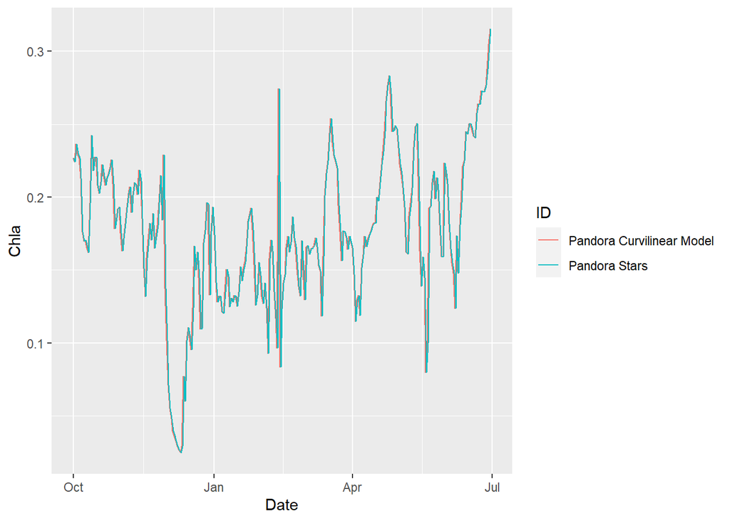

```r
#filter data to get what we want
model_only <- all_data |>
  filter(Type == "Point",
         Freq == "Daily",
         ID %in% c("Pandora Curvilinear Model", "Pandora Stars"),
         between(Date, as.Date("2021-10-01"), as.Date("2022-06-30")),
         !c(ID == "Pandora Curvilinear Model" & Depth == "5m"))

#plot
model_only |> ggplot(aes(x = Date, y = Chla, group = ID, color = ID)) +
  geom_line(position = position_dodge(width = 1))
```

```r
#save
ggsave(glue("{save_outputs}/pandora_model_only.png"))
```

This looks perfect.

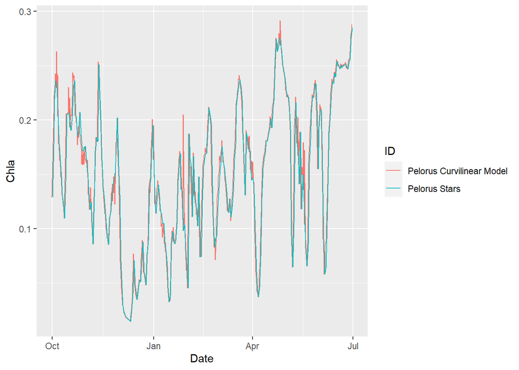

```r
#filter data to get what we want
model_only <- all_data |>
  filter(Type == "Point",
         Freq == "Daily",
         ID %in% c("Pelorus Curvilinear Model", "Pelorus Stars"),
         between(Date, as.Date("2021-10-01"), as.Date("2022-06-30")),
         !c(ID == "Pandora Curvilinear Model" & Depth == "5m"))

#plot
model_only |> ggplot(aes(x = Date, y = Chla, group = ID, color = ID)) +
  geom_line(position = position_dodge(width = 1))
```

```r
#save
ggsave(glue("{save_outputs}/pelorus_model_only.png"))
```

And same with this one, spot on. Now, knowing that the stars model is returing the correct results, we can move on to comparing model data against the loggers.

## 4.2 Pandora

First we will look at Pandora MMP daily logger data at a depth of 5m vs. stars model data at a depth of 0m vs. curvilinear model data at a depth of 0m for the time period 2021-10-01 to 2022-06-30.

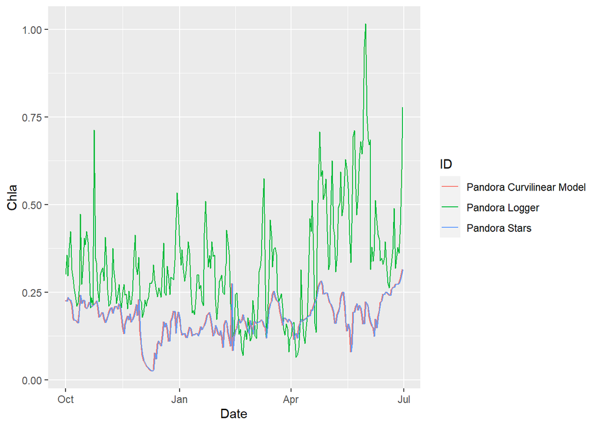

```r
#filter data to get what we want
pandora_set_1 <- all_data |>
  filter(Type == "Point",
         Freq == "Daily",
         ID %in% c("Pandora Logger", "Pandora Curvilinear Model", "Pandora Stars"),
         between(Date, as.Date("2021-10-01"), as.Date("2022-06-30")),
         !c(ID == "Pandora Curvilinear Model" & Depth == "5m"))

#plot
pandora_set_1 |> ggplot(aes(x = Date, y = Chla, group = ID, color = ID)) +
  geom_line(position = position_dodge(width = 1))
```

```r
#save
ggsave(glue("{save_outputs}/padora_set_1.png"))
```

Below we extent the dates and add the 5m depth.

(Note there is missing data in the logger from 2020 09 until 2021 02).

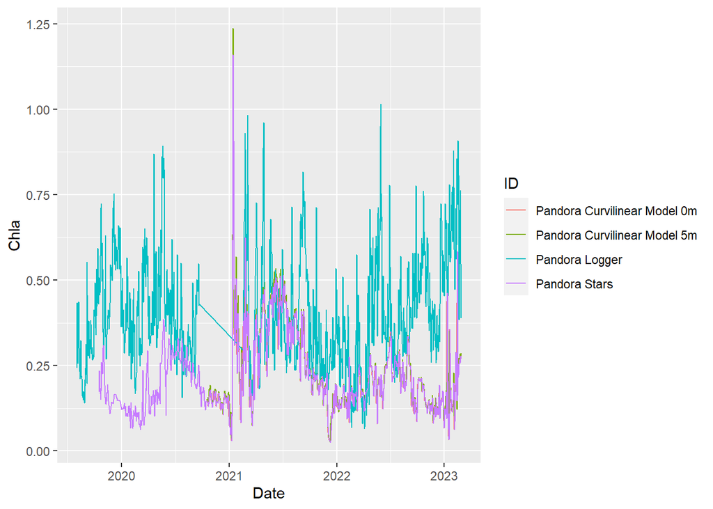

```r
#filter data to get what we want
pandora_set_2 <- all_data |>
  filter(Type == "Point",
         Freq == "Daily",
         ID %in% c("Pandora Logger", "Pandora Curvilinear Model", "Pandora Stars"),
         between(Date, as.Date("2019-08-01"), as.Date("2023-02-28"))) |>
  mutate(ID = case_when(str_detect(Depth, "5m") & str_detect(ID, "Curvi") ~ "Pandora Curvilinear Model 5m",
                        str_detect(Depth, "0m") & str_detect(ID, "Curvi") ~ "Pandora Curvilinear Model 0m",
                        T ~ ID))

#plot
pandora_set_2 |> ggplot(aes(x = Date, y = Chla, group = ID, color = ID)) +
  geom_line(position = position_dodge(width = 1))
```

```r
#save
ggsave(glue("{save_outputs}/padora_set_2.png"))
```

That is not noticeably better, and generally seems to underestimate concentrations. Interestingly, the change in depth had little impact (the 5m data is basically hidden behind the 0m data. It should be noted that this is for a very near-shore environment (lots and lots of confounding factors for the model to account for) and only for one cell. Therefore, next up we will take the mean of a small area around the point to see if that makes a difference.

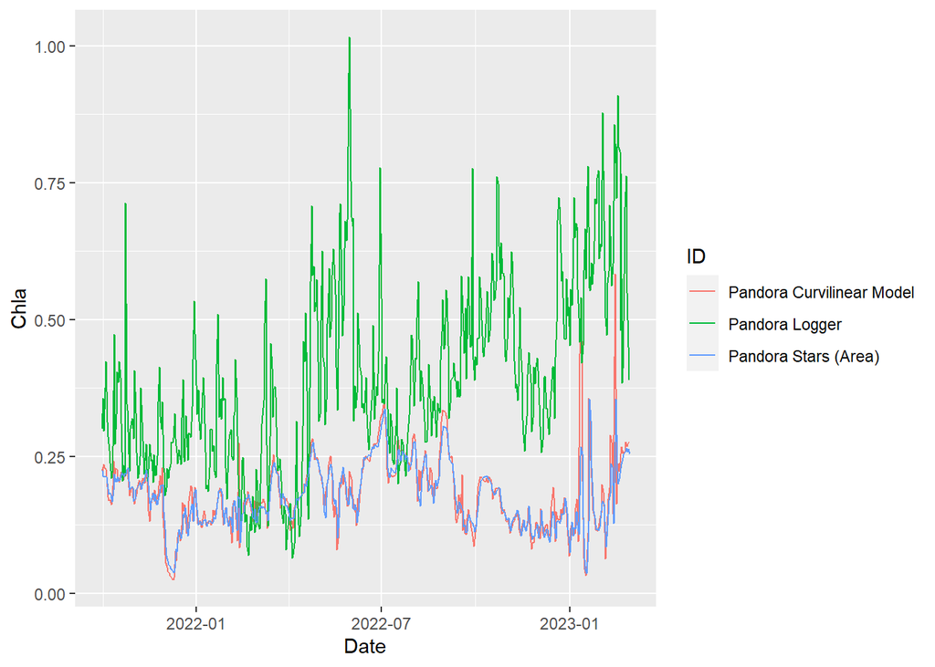

```r
#filter data to get what we want
pandora_set_3 <- all_data |>
  filter(Freq == "Daily",
         ID %in% c("Pandora Logger", "Pandora Curvilinear Model", "Pandora Stars"),
         between(Date, as.Date("2021-10-01"), as.Date("2023-02-28")),
         !c(ID == "Pandora Curvilinear Model" & Depth == "5m"),
         !c(ID == "Pandora Stars" & Type == "Point")) |>
  mutate(ID = case_when(str_detect(ID, "Stars") ~ "Pandora Stars (Area)",
                        T ~ ID))

#plot
pandora_set_3 |> ggplot(aes(x = Date, y = Chla, group = ID, color = ID)) +
  geom_line(position = position_dodge(width = 1))
```

```r
#save
ggsave(glue("{save_outputs}/padora_set_3.png"))
```

Here we see that taking the average of an area 0.075 degrees around the point of interest doesn’t seem to change things too much either from just the single point, only smoothing things out somewhat. What about for a logger in a different location? Keeping in mind that all loggers that we testing are relatively close to shore and will all be affected by the myriad of local dynamics that are very hard to model.

## 4.3 Pelorus

Now we can begin the comparisons at the Pelorus Site

First we will look at Pelorus MMP daily logger data at a depth of 5m vs. stars model data at a depth of 0m vs. curvilinear model data at a depth of 0m for the time period 2021-10-01 to 2022-06-30. (The same as the first analysis we did at the Pandora Site).

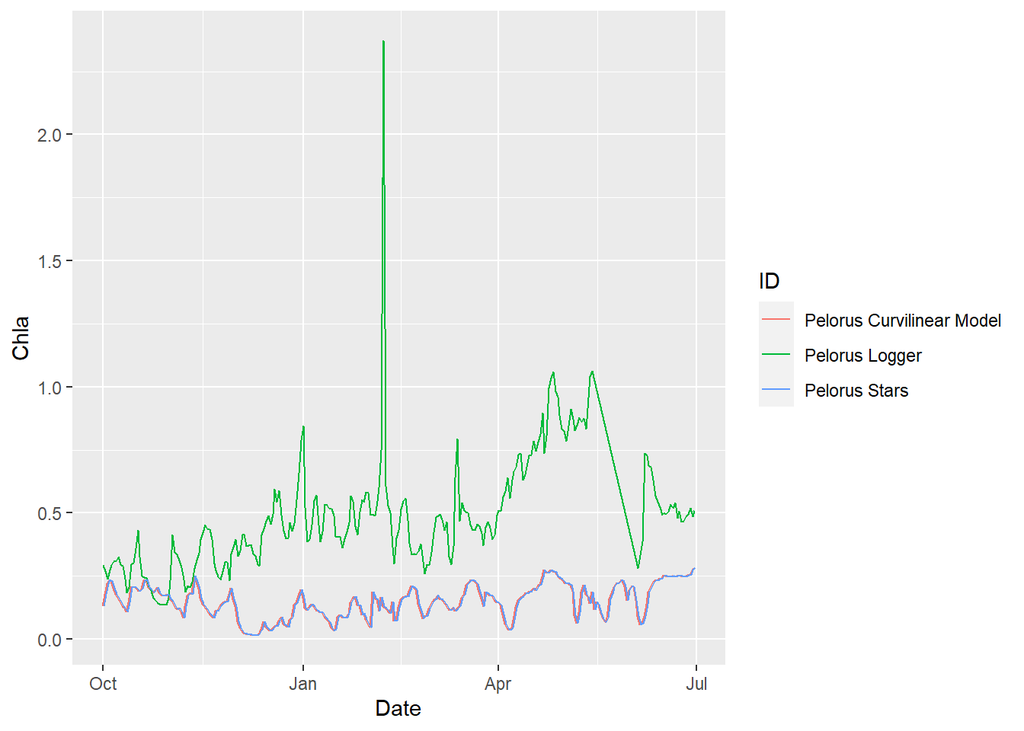

```r
#filter data to get what we want
pelorus_set_1 <- all_data |>
  filter(Type == "Point",
         Freq == "Daily",
         ID %in% c("Pelorus Logger", "Pelorus Curvilinear Model", "Pelorus Stars"),
         between(Date, as.Date("2021-10-01"), as.Date("2022-06-30")),
         !c(ID == "Pelorus Curvilinear Model" & Depth == "5m"))

#plot
pelorus_set_1 |> ggplot(aes(x = Date, y = Chla, group = ID, color = ID)) +
  geom_line(position = position_dodge(width = 1))
```

```r
#save
ggsave(glue("{save_outputs}/pelorus_set_1.png"))
```

Almost the exact same issue. To confirm this assessment we will complete the same two comparisons as we did above, one for a long period of time, and one for an area around the point.

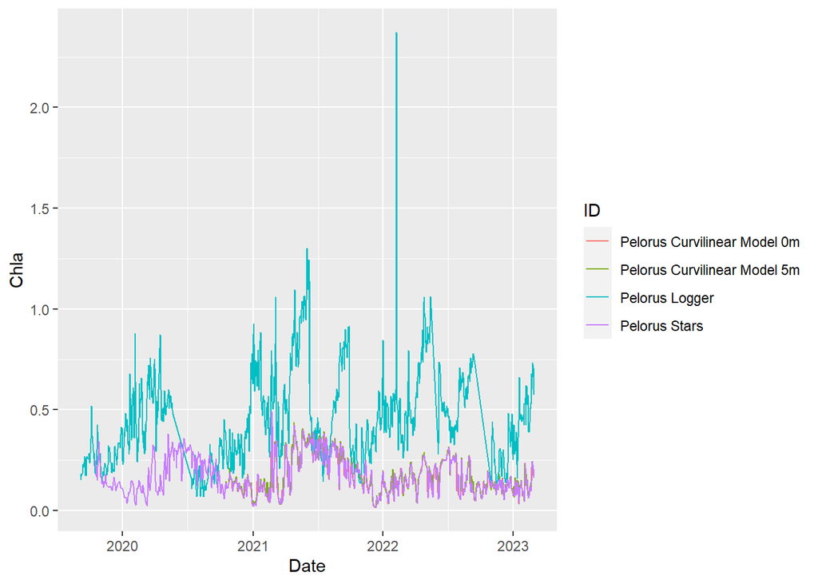

```r
#filter data to get what we want
pelorus_set_2 <- all_data |>
  filter(Type == "Point",
         Freq == "Daily",
         ID %in% c("Pelorus Logger", "Pelorus Curvilinear Model", "Pelorus Stars"),
         between(Date, as.Date("2019-08-01"), as.Date("2023-02-28"))) |>
  mutate(ID = case_when(str_detect(Depth, "5m") & str_detect(ID, "Curvi") ~ "Pelorus Curvilinear Model 5m",
                        str_detect(Depth, "0m") & str_detect(ID, "Curvi") ~ "Pelorus Curvilinear Model 0m",
                        T ~ ID))

#plot
pelorus_set_2 |> ggplot(aes(x = Date, y = Chla, group = ID, color = ID)) +
  geom_line(position = position_dodge(width = 1))
```

```r
#save
ggsave(glue("{save_outputs}/pelorus_set_2.png"))
```

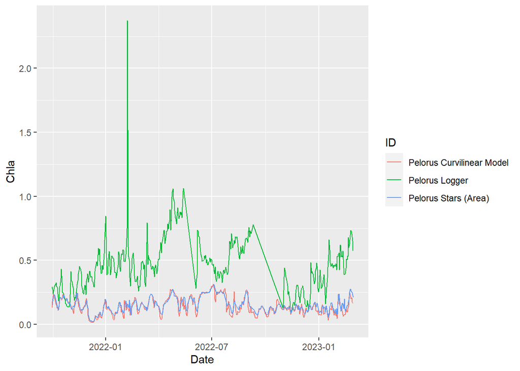

```r
#filter data to get what we want
pelorus_set_3 <- all_data |>
  filter(Freq == "Daily",
         ID %in% c("Pelorus Logger", "Pelorus Curvilinear Model", "Pelorus Stars"),
         between(Date, as.Date("2021-10-01"), as.Date("2023-02-28")),
         !c(ID == "Pelorus Curvilinear Model" & Depth == "5m"),
         !c(ID == "Pelorus Stars" & Type == "Point")) |>
  mutate(ID = case_when(str_detect(ID, "Stars") ~ "Pelorus Stars (Area)",
                        T ~ ID))

#plot
pelorus_set_3 |> ggplot(aes(x = Date, y = Chla, group = ID, color = ID)) +
  geom_line(position = position_dodge(width = 1))
```

```r
#save
ggsave(glue("{save_outputs}/pelorus_set_3.png"))
```

In this case we can see that the long term data also does not line up as close, further suggesting the complexity and difficulty of inshore modelling. For the area sample the finding are the same, sampling a small area around the point makes little difference other than to smooth at some of the more erratic changes in values.

The next thing to consider is a specific quirk of sampling. The MMP loggers actually record hourly data, and then the daily data is presented as the mean of this. However, per. comms. with Eric Lawrey (need to double check this), the models “daily” figure is actually a snapshot of midday conditions, rather than a mean of hourly conditions for the day. Therefore, perhaps discrepancies are due to the specific hour the sample is taken.

Below we look at intra-day details, first we will pick a random day and see how values change each hour.

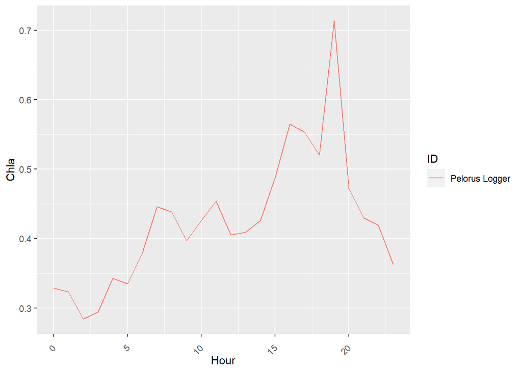

```r
#filter to get what we want
pelorus_set_4 <- all_data |>
  filter(Freq == "Hourly",
         Date == as.Date("2023-02-05"))

#plot
pelorus_set_4 |> ggplot(aes(x = Hour, y = Chla, group = ID, color = ID)) +
  geom_line() +
  theme(axis.text.x = element_text(angle = 45, vjust = 0.5, hjust=1))
```

```r
#save
ggsave(glue("{save_outputs}/pelorus_set_4.png"))
```

Clearly there is a significant difference in Chla concentrations depending on the time of day, but again, this might just be a quirk of the specific date chosen. Thus we will take all days and get the mean of each hour. For context we will also overlay the day mean, to understand how that would look in comparison.

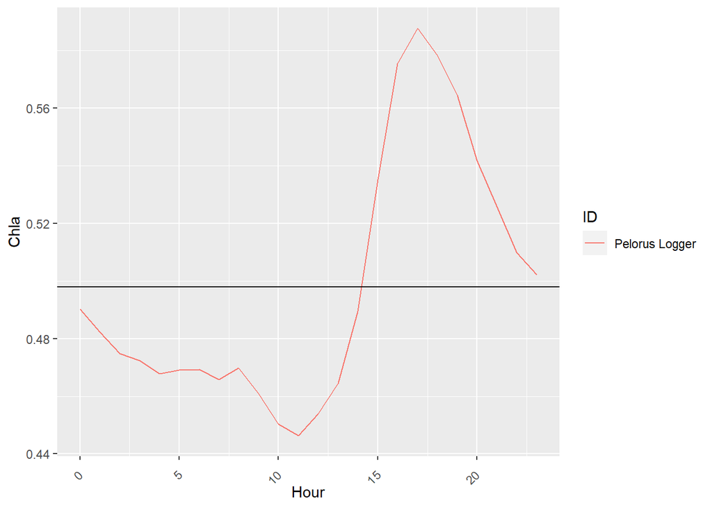

```r
#filter to get what we want
pelorus_set_5 <- all_data |>
  filter(Freq == "Hourly") |>
  group_by(ID, Hour) |> summarise(Chla = mean(Chla)) |> ungroup()

total_chla <- mean(pelorus_set_5$Chla)

#plot
pelorus_set_5 |> ggplot(aes(x = Hour, y = Chla, group = ID, color = ID)) +
  geom_line() +
  theme(axis.text.x = element_text(angle = 45, vjust = 0.5, hjust=1)) +
  geom_hline(yintercept = total_chla)
```

```r
#save
ggsave(glue("{save_outputs}/pelorus_set_5.png"))
```

Regardless, lets take a look at how the logger data compares to the model data, if we exclusively get out logger data at midday.

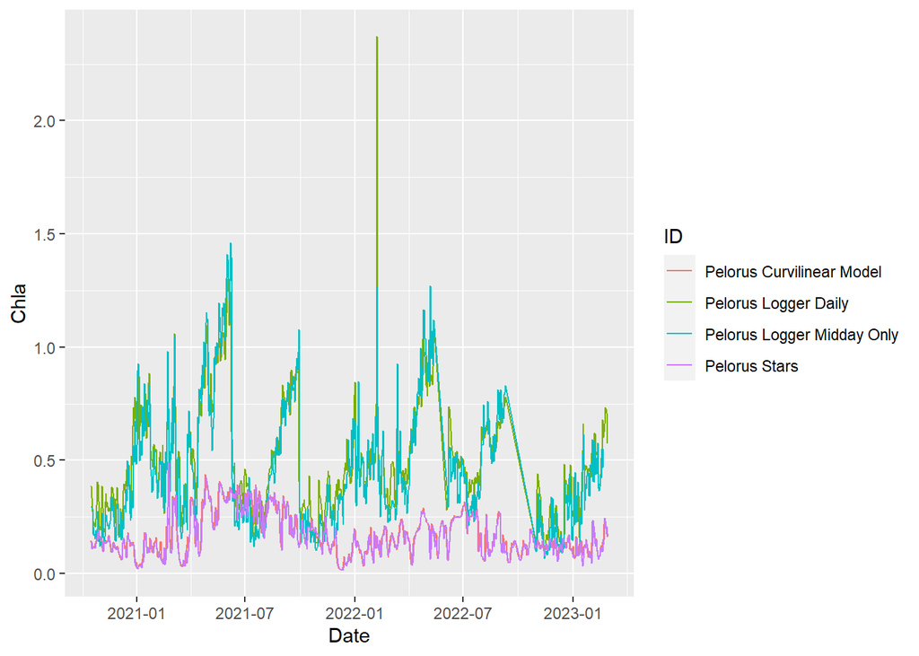

```r
#filter to get what we want
pelorus_set_6_part_1 <- all_data |>
  filter(Freq == "Hourly",
         Hour == "12") |>
  mutate(ID = "Pelorus Logger Midday Only")

pelorus_set_6_part_2 <- all_data |>
  filter(ID == "Pelorus Logger",
         Freq == "Daily") |>
  mutate(ID = "Pelorus Logger Daily")

pelorus_set_6_part_3 <- all_data |>
  filter(ID == "Pelorus Curvilinear Model",
         Depth == "5m")

pelorus_set_6_part_4 <- all_data |>
  filter(ID == "Pelorus Stars",
         Type == "Point")

pelorus_set_6 <- rbind(pelorus_set_6_part_1, pelorus_set_6_part_2, pelorus_set_6_part_3, pelorus_set_6_part_4) |>
  filter(between(Date, as.Date("2020-10-16"), as.Date("2023-02-28")))

#plot
pelorus_set_6 |> ggplot(aes(x = Date, y = Chla, group = ID, color = ID)) +
  geom_line(position = position_dodge(width = 1))
```

```r
#save
ggsave(glue("{save_outputs}/pelorus_set_6.png"))
```

Again, no massive change is visible, but it does reduce the gap somewhat.

To summarise/confirm where we are at now, both model and logger are now sampling at 5m, both are sampling at midday, both are sampling total chlorophyll, both are using the same units, and both are in the same spot.

Thus differences are a result of (i am assuming) the extreme difficulty in modelling the near shore environment.

# 5 Session Info

Below is the session info at the time of rendering this script. Of greatest importance is to note the R version, and the “other attached packages” as these are the most significant drivers of success/failure. It is also good to check the “attached base packages” and “loaded via a namespace” packages as well. To check your session info use `sessionInfo()`.

[session information not shown]